# **Milestone 1**

## **1. Univariate Analysis - Numerical Data**

Histograms and box plots help to visualize and describe numerical data. We use box plot and histogram to analyse the numerical columns.

```python
# Let us write a function that will help us create a boxplot and histogram for any input numerical variable.
# This function takes the numerical column as the input and returns the boxplots and histograms for the variable.

def histogram_boxplot(feature, figsize = (15, 10), bins = None):

    """ Boxplot and histogram combined

    feature: 1-d feature array

    figsize: size of fig (default (9, 8))

    bins: number of bins (default None / auto)

    """
    f2, (ax_box2, ax_hist2) = plt.subplots(nrows = 2, # Number of rows of the subplot grid = 2
                                           sharex = True, # X-axis will be shared among all subplots
                                           gridspec_kw = {"height_ratios": (.25, .75)},
                                           figsize = figsize
                                           ) # Creating the 2 subplots

    sns.boxplot(feature, ax = ax_box2, showmeans = True, color = 'violet') # Boxplot will be created and a symbol will indicate the mean value of the column

    sns.distplot(feature, kde = F, ax = ax_hist2, bins = bins, palette = "winter") if bins else sns.distplot(feature, kde = False, ax = ax_hist2) # For histogram

    ax_hist2.axvline(np.mean(feature), color = 'green', linestyle = '--') # Add mean to the histogram

    ax_hist2.axvline(np.median(feature), color = 'black', linestyle = '-') # Add median to the histogram
```

**Let us plot histogram and box-plot for the feature 'Kilometers_Driven' to understand the distribution and outliers, if any.**

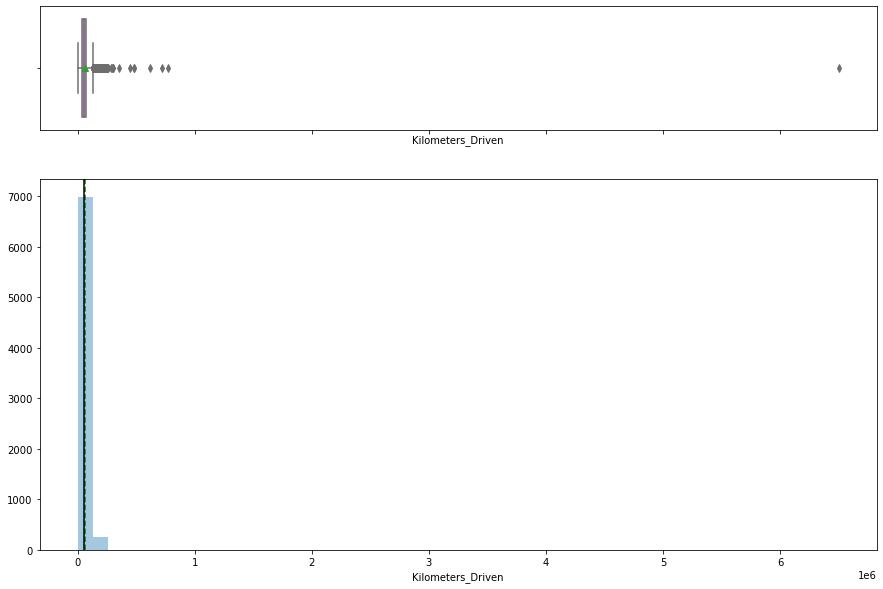

```python
# Plot histogram and box-plot for 'Kilometers_Driven'
histogram_boxplot(data['Kilometers_Driven'])
```

**Think About It**: Kilometers_Driven is highly right-skewed. Can we use Log transformation of the feature to reduce/remove the skewness? Why can't we keep skewed data?

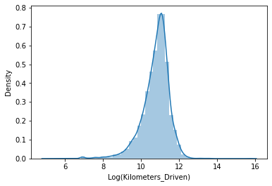

```python
# Log transformation of the feature 'Kilometers_Driven'
sns.distplot(np.log(data["Kilometers_Driven"]), axlabel = "Log(Kilometers_Driven)");
```

**Observations and Insights:**

- Kilometers driven is even distrubuted

```python
# We can add a transformed kilometers_driven feature in data
df["kilometers_driven_log"] = np.log(df["Kilometers_Driven"])
```

**Note:** Like Kilometers_Driven, the distribution of Price is also highly skewed, we can use log transformation on this column to see if that helps normalize the distribution. And add the transformed variable into the dataset. You can name the variable as **'price_log'**.

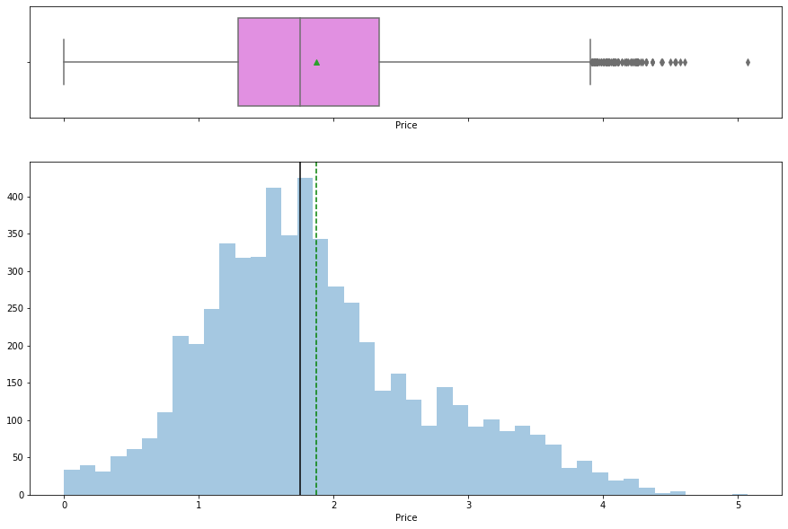

```python
# Plot histogram and box-plot for 'Price'
histogram_boxplot(df['Price'])
```

[output not shown]

[figure not shown]

```python
# Log transformation of the feature 'Price'
sns.distplot(np.log(data["Price"]), axlabel = "Log(Price)");
```

```python
# We can Add a transformed Price feature in data
data["price_log"] = np.log(data["Price"])
```

**Note:** Try plotting histogram and box-plot for different numerical features and understand how the data looks like.

**Observations and Insights for all the plots:**

- The graph is almost evenly distributed, with the mean being in between 1-2

## **2. Univariate analysis - Categorical Data**

```python
# Let us write a function that will help us create barplots that indicate the percentage for each category.
# This function takes the categorical column as the input and returns the barplots for the variable.

def perc_on_bar(z):
    '''
    plot
    feature: categorical feature
    the function won't work if a column is passed in hue parameter
    '''

    total = len(data[z]) # Length of the column

    plt.figure(figsize = (15, 5))

    ax = sns.countplot(data[z], palette = 'Paired', order = data[z].value_counts().index)

    for p in ax.patches:

        percentage = '{:.1f}%'.format(100 * p.get_height() / total) # Percentage of each class of the category

        x = p.get_x() + p.get_width() / 2 - 0.05 # Width of the plot

        y = p.get_y() + p.get_height()           # Hieght of the plot

        ax.annotate(percentage, (x, y), size = 12) # Annotate the percantage

    plt.show() # Show the plot
```

**Let us plot barplot for the variable location. It will be helpful to know the number of percentage of cars from each city.**

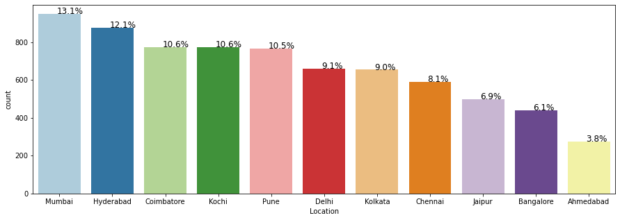

```python
# Bar Plot for 'Location'
perc_on_bar('Location')
```

**Note:** Explore for other variables like Year, Fuel_Type, Transmission, Owner_Type`.

**Observations and Insights from all plots:**

## **Bivariate Analysis**

### **1. Scatter plot**

A scatter plot allows us to see relationships between two variables.

**Note: Use log transformed values 'kilometers_driven_log' and 'price_log'**

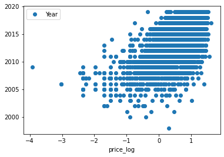

```python
# Let us plot pair plot for the variables 'year' and 'price_log'
data.plot(x = 'price_log', y = 'Year', style = 'o')
```

**Note:** Try to explore different combinations of independent variables and dependent variable. Understand the relationship between all variables.

**Observations and Insights from all plots:**

- The plots are scattered, but there's a slight upward movement
- Price_log increases as the year increases

### **2. Heat map**

Heat map shows a 2D correlation matrix between two numerical features.

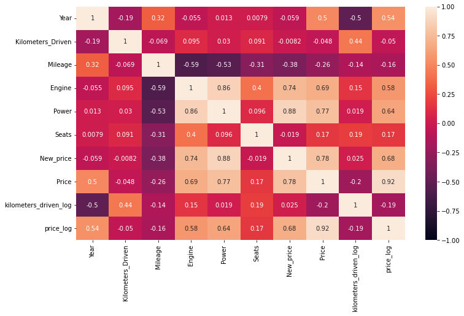

```python
# We can include the log transformation values and drop the original skewed data columns
plt.figure(figsize = (12, 7))

sns.heatmap(data.corr(), annot = True, vmin = -1, vmax = 1)

plt.show()
```

**Observations and Insights:**

- Engine and Power and highly correlated
- Power is also correlated with New_price and Price
- Mileage is negatively correlated with Engine and Power
- Power isn't affected by the number of seats
- Power isn't affected by the year of production

### **3. Box plot**

```python
# Let us write a function that will help us create boxplot w.r.t Price for any input categorical variable.
# This function takes the categorical column as the input and returns the boxplots for the variable.
def boxplot(z):

    plt.figure(figsize = (12, 5)) # Setting size of boxplot

    sns.boxplot(x = z, y = data['Price']) # Defining x and y

    plt.show()

    plt.figure(figsize = (12, 5))

    plt.title('Without Outliers')

    sns.boxplot(x = z, y = data['Price'], showfliers = False) # Turning off the outliers

    plt.show()
```

#### Let us now plot bivariate analysis of target variable with a categorical variable 'Location'

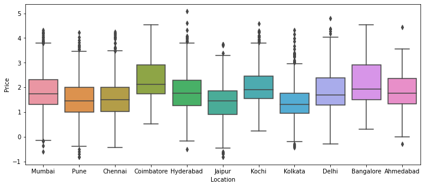

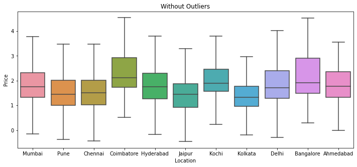

```python
# Box Plot: Price vs Location
boxplot(data['Location'])
```

**Note:** Explore by plotting box-plots for target variable and the other categorical variables like Fuel_Type, transmission, Owner_type.

**Observations and Insights for all plots:**

### **Feature Engineering**

**Think about it:** The `Name` column in the current format might not be very useful in our analysis. Since the name contains both the brand name and the model name of the vehicle, the column would have too many unique values to be useful in prediction. Can we extract that information from that column?

- **Hint:** With 2041 unique names, car names are not going to be great predictors of the price in our current data. But we can process this column to extract important information for example brand name.

#### **Observations and Insights:**

- The column "Name" contains both Brands and Name of the manufacturer. We'll have to seperate them into their own columns to utilize the info in the sections below

### **Missing value treatment**

```python
# Now check the missing values of each column. Hint: Use isnull() method
num_missing = df.isnull().sum(axis = 1)
num_missing.value_counts()
```

```
0    5780
dtype: int64
```

**Observations and Insights:**

**Missing values in Seats**

```python
# Checking missing values in the column 'Seats'
df["Seats"].isna().sum()
```

```
0
```

**Think about it:** Can we somehow use the extracted information from 'Name' column to impute missing values?

**Hint:** Impute these missing values one by one, by taking median number of seats for the particular car, using the Brand and Model name.

```python
# Impute missing values in Seats,you can use fillna method in pandas
# df["Seats"] = df.groupby(["Brand", "Model"]).apply(lambda x:x.fillna(x.median()))
```

```python
# Now check total number of missing values of the seat column to verify if they are imputed or not. Hint: Use isnull() method
df["Seats"].isna().sum()
```

```
0
```

**Missing values for Mileage**

```python
# Now check missing values of each column. Hint: Use isnull() method
num_missing = df.isnull().sum(axis=1)
num_missing.value_counts()
```

```
0    5780
dtype: int64
```

```python
# Impute missing Mileage. For example, use can use median or any other methods.
```

```python
# Now check total number of missing values of the seat column to verify if they are imputed or not. Hint: Use isnull() method
```

**Missing values for Engine**

```python
df["Engine"].isna().sum()
```

```
0
```

**Missing values for Power**

```python
df["Power"].isna().sum()
```

```
0
```

**Missing values for New_price**

```python
df["New_price"].isna().sum()
```

```
0
```

**Observations for missing values after imputing:**

- The number of missing values should decrease after imputing. If we still see missing values,then we'll have to explore the data further to remove these values

## **Proposed approach**

- **Potential techniques -** What different techniques should be explored?
  - our Priority should be to clean the data (isnull is an option)
  - check to see if there's missing data (num_missing is an option)
  - check to see if there are any outliers, exceptions, or na's in the data. this can skew the data and our observations. we can locate outliers and exceptions by creating graphs
  - determine and fill in any missing data (we can using grouping to do this)
  - use graphs to determine any correlations (we can use heatmap, pairplots, distplots, etc.)
  - build a model, train, and test it (use dummy variables, and olsmodel)
  - check statmodel (use olsmodel)
  - check rmse, mae, mape
  - check for multicolinearity, heteroscedasticity, linearity
- **Overall solution design -** What is the potential solution design?
  - first we need to clean the data
  - use graphs or charts to understand any correlation or pattern
  - check the data to see if it's skewed
  - build a model, train, and test it
  - check statmodel
- **Measures of success -** What are the key measures of success?
  - we want to observe if there's any correlation between cars being bought and features. This will help us determine what type of cars are being bought, and what features are being requested.
  - it would also help if we could determine a pattern by location; Are more cars being sold in larger cities, are certain features being requested in a region, etc.
  - it would be a success if we can determine any correlations between features and price. help us understand what's selling, what features are people looking for, and what features determine the price.

### **Saving the Data**

Please save the pre-processed dataset into a separate file so that we can continue without having to repeat the work we did in Milestone1. The stored data frame can be loaded into Milestone2 and implemented further.

To save the pre-processed data frame, please follow the below lines of code:

```python
# Assume df_cleaned is the pre-processed data frame in your code, then
df_cleaned.to_csv("cars_data_updated.csv", index = False)
```

The above code helps to save the cleaned/pre-processed dataset into csv file, that can be further loaded into Milestone2.